# SR_w6

Jake VanCampen

2018-02-19

The data described in this report come from an RNA-seq experiment from the brood pouch of 12 male pipefish, half of whom were pregnant. First the data will be explored, and described. Then I will investigate the gene expression differences between pregnant and non-pregnant fish, and compare that to the variation in gene expression between individual fish.

Then, a 10-gene ‘pregnancy test’ will be designed using robust logistic regression for those 10 genes.

```r
pipefish_data <- read_tsv('./Data/pipefish_RNAseq_CPM.tsv')

head(pipefish_data)
```

```
## # A tibble: 6 x 15
##           Gene_ID       P09       P08      P07      P06       P05
##             <chr>     <dbl>     <dbl>    <dbl>    <dbl>     <dbl>
## 1 SSCG00000000005 133.43118 103.43163 90.48202 77.46096  35.32357
## 2 SSCG00000000007  56.01645  50.86686 52.76063 47.39327  44.85447
## 3 SSCG00000000008  44.02893  25.25656 40.18684 27.31759  29.13118
## 4 SSCG00000000009  47.10983  40.18411 44.21374 52.25177  37.04667
## 5 SSCG00000000010  61.11395  67.56307 82.42821 67.74396 153.08676
## 6 SSCG00000000011  18.76551  23.13416 19.88796 23.00911  23.63879
## # ... with 9 more variables: P03 <dbl>, N11 <dbl>, N10 <dbl>, N04 <dbl>,
## #   N03 <dbl>, N02 <dbl>, N01 <dbl>, blast_hit_description <chr>,
## #   KEEG_ortholog_ID <chr>
```

```r
nrow(pipefish_data)
```

```
## [1] 1000
```

The data are described by normalized counts for each of the 1000 genes, for each of the 12 samples (columns).

We can get some idea of how the counts are distributed across all genes by viewing a histogram of their counts.

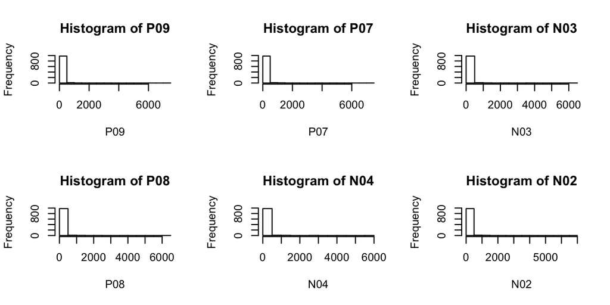

```r
layout(matrix(1:6, 2, 3))
with(pipefish_data, {
  hist(P09)
  hist(P08)
  hist(P07)
  hist(N04)
  hist(N03)
  hist(N02)
})
```

The counts do not look normally distributed.. we can again check for normality by looking at the normal QQ plot for the same individuals.

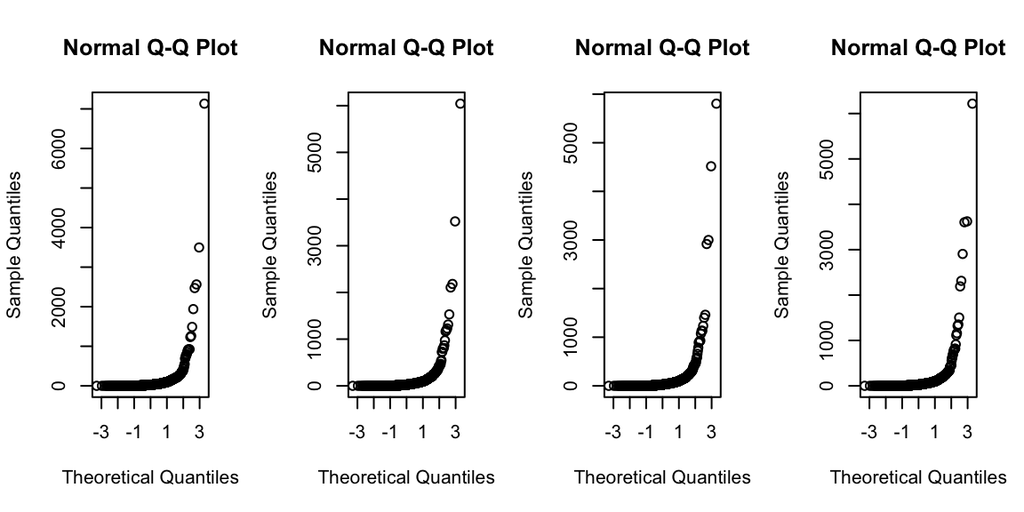

```r
layout(t(1:4))
qqnorm(pipefish_data$P09)
qqnorm(pipefish_data$P08)
qqnorm(pipefish_data$N01)
qqnorm(pipefish_data$N03)
```

I could also be interesting to look at the distribution of counts for each gene, though there are a lot, so maybe we’ll just look at a distribution of the variance of counts in each gene.

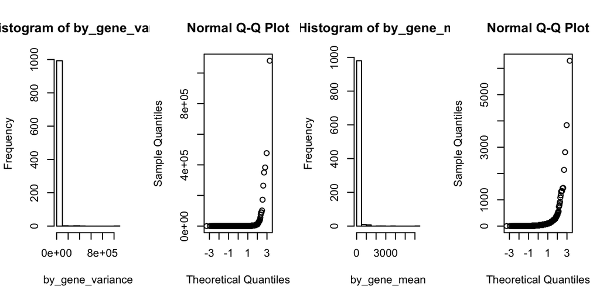

```r
layout(t(1:4))
by_gene_variance <- rowVars(as.matrix(pipefish_data[2:13]))
hist(by_gene_variance)
qqnorm(by_gene_variance)

by_gene_mean <- rowMeans(pipefish_data[2:13])
hist(by_gene_mean)
qqnorm(by_gene_mean)
```

It is clear that both the mean and the variance of the counts per gene are not normally distributed, and have large outliers. This is also the case for the per, individual counts. The normal QQ plots tell us that the noise is not normal, and that to correctly model these data we will need to fit a model with a non-gaussian noise component to be robust to the outliers in our data.

```r
## scale with robust statistics
scaled_pipefish <- lapply(pipefish_data[2:13], function(x){
  x <- x - median(x) /  mad(x)
})

scaled_pipefish <- as.matrix(data.frame(scaled_pipefish))
```

We want to fit a model to determine the difference in mean gene expression between pregnant and non-pregnant fish. To do this we can fit a stan model with non-gaussian (Cauchy noise). With a data matrix of 1000 X 12, we are interested in describing how the mean gene expression between the groups is different.

We can describe the response gene expression ‘y’ as a cauchy, with center ‘b + alpha * p’ describing the mean gene expression for pregnant vs. non-pregnant fish, and scale ‘epsilon’, as follows:

$${y}= cauchy({b_0} + \alpha * p, \epsilon)$$

## The stan model

```r
pipefish_mod <- "
data {
    int N; // number of obs (1000)
    int m; // number of individuals
    matrix[N, m] y; // data vector (by gene expression)
    row_vector[m] p; // pregnancy status c(rep(1,6), rep(0,6))
}
parameters {
    vector[N] b; // mean expresison for non-pregnent
    vector[N] a; // mean expression for pregnant

    vector<lower=0>[N] epsilon; // per gene error rate

    real<lower=0> df_a;
    real<lower=0> df_b;

    real<lower=0> sigma_b;
    real<lower=0> sigma_a;

    real mu_a;
    real mu_b;

}
model {

    for(i in 1:N){
       for(j in 1:m){
         y[i][j] ~ cauchy(b[i] + a[i]* p[j], epsilon[i]);
       }
    }

    b ~ student_t(df_b, mu_b, sigma_b);
    a ~ student_t(df_a, mu_a, sigma_a);

    // priors on b
    mu_b ~ normal(0, 10);
    sigma_b ~ normal(0, 10);
    df_b ~ normal(0, 20);

    // priors on a
    mu_a ~ normal(0, 10);
    sigma_a ~ normal(0, 10);
    df_a ~ normal(0, 20);

    // priors on epsilon
    epsilon ~ normal(0, 10);
}
"

data_list <- list(N=nrow(scaled_pipefish),
                  y=scaled_pipefish,
                  m=ncol(scaled_pipefish),
                  p=c(rep(1,6), rep(0,6)))

#pipe_fit <- stan(model_code = pipefish_mod, data=data_list,
#                iter=500, chains = 3,
#                control=list(adapt_delta=0.99, max_treedepth=15))
```

The model was run and, and saved in a .RData file. The data can be read in as follows.

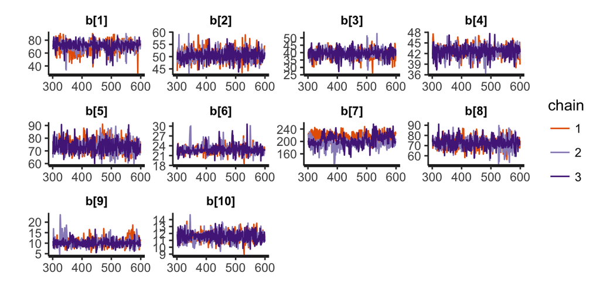

```r
# trick to save run for later
pipe_fit <- readRDS("pipe_fit.rds")


stan_trace(pipe_fit)
```

```r
# fuzzy!

# investigate Rhat, n_eff
head(summary(pipe_fit)$summary, 20)
```

```
##              mean     se_mean         sd        2.5%         25%
## b[1]   70.9132622 0.635240555  8.4509247  50.6192961  66.6781064
## b[2]   50.5349529 0.082902809  2.4870843  45.8521677  48.9175040
## b[3]   39.3139109 0.110379137  3.3113741  32.2772109  37.3422643
## b[4]   42.7252730 0.057840986  1.6092219  39.1476482  41.7573925
## b[5]   73.6557457 0.169304080  5.0791224  64.2673153  70.2329664
## b[6]   22.8108661 0.051722756  1.2715233  20.4423306  22.1594896
## b[7]  204.7175755 9.056548555 18.5177720 166.8466180 193.9961213
## b[8]   72.6607134 0.183869101  5.5160730  61.6434924  69.3925754
## b[9]   10.4249415 0.151214257  2.0253868   7.0640093   9.1749240
## b[10]  11.5511757 0.024547264  0.7364179  10.1593687  11.0301584
## b[11]   8.7700443 0.045166706  1.1651399   6.9395708   8.0446259
## b[12]  79.3477726 0.459962273  5.3378847  67.2712949  76.6281497
## b[13]   7.2352223 0.027557147  0.8267144   5.7161671   6.6929148
## b[14]  76.5993656 0.398389220  5.2987139  68.8876909  73.1961994
## b[15]   0.4580396 0.012724137  0.3817241  -0.2893007   0.2198559
## b[16]  21.7328335 0.053716590  1.6114977  18.5848166  20.6485138
## b[17]  25.1125205 0.052983781  1.5895134  22.0763256  24.1189065
## b[18]   0.5078185 0.007747021  0.2237473   0.1343887   0.3568251
## b[19]   7.6073298 0.027773700  0.8332110   5.9730153   7.1086991
## b[20]  14.7475793 0.033265894  0.9979768  12.7626009  14.0840226
##               50%         75%      97.5%      n_eff      Rhat
## b[1]   72.2735862  76.2824965  84.507517 176.983197 1.0177321
## b[2]   50.4132193  52.0901559  55.538613 900.000000 1.0005706
## b[3]   39.3519025  41.5900367  45.540318 900.000000 0.9973967
## b[4]   42.8134162  43.7933050  45.636461 774.034792 1.0031498
## b[5]   73.2571093  76.9520282  84.497064 900.000000 0.9984100
## b[6]   22.7000850  23.3550843  25.697060 604.345601 1.0026113
## b[7]  203.5883318 217.4184997 239.682085   4.180729 1.2172364
## b[8]   72.7931511  75.8114772  83.693275 900.000000 1.0015228
## b[9]   10.2310524  11.4162431  15.538033 179.403324 1.0087143
## b[10]  11.5215080  12.0421382  13.059095 900.000000 1.0003770
## b[11]   8.5258962   9.3667936  11.389193 665.455890 1.0061162
## b[12]  80.0923190  82.8416398  88.162386 134.677162 1.0162156
## b[13]   7.2054361   7.6784055   9.087796 900.000000 1.0026351
## b[14]  75.5953081  78.9055527  89.870008 176.899165 1.0131531
## b[15]   0.4533807   0.6725504   1.246947 900.000000 0.9989367
## b[16]  21.7247350  22.8723947  24.697407 900.000000 0.9970509
## b[17]  25.0197087  26.0096663  28.574773 900.000000 0.9977893
## b[18]   0.4906215   0.6436607   1.012521 834.153486 0.9976372
## b[19]   7.5962434   8.1102800   9.440428 900.000000 0.9983218
## b[20]  14.7054487  15.4351742  16.604451 900.000000 0.9975928
```

```r
#Extract posterior
post1 <- extract(pipe_fit)
```

We are interested how the mean gene expression of pregnant and non-pregnant males differ, relative to inter individual variation. To answer this question we can look at the expression difference between genes. We next want to compare how mu_a (the variation in mean expression per gene) compares to epsilon (the overall variation in gene expression that can be explained by individual).

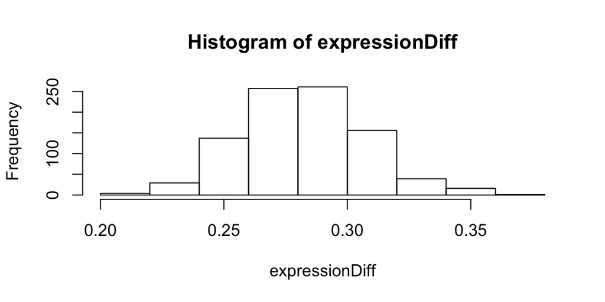

```r
#Calculate vector of mean expression difference for each gene
expressionDiff <- 1 - (pt((1-post1$mu_a)/post1$sigma_a, df=post1$df_a) - pt((-1-post1$mu_a)/post1$sigma_a, df=post1$df_a))

# histogram of the expression difference for each gene
hist(expressionDiff)
```

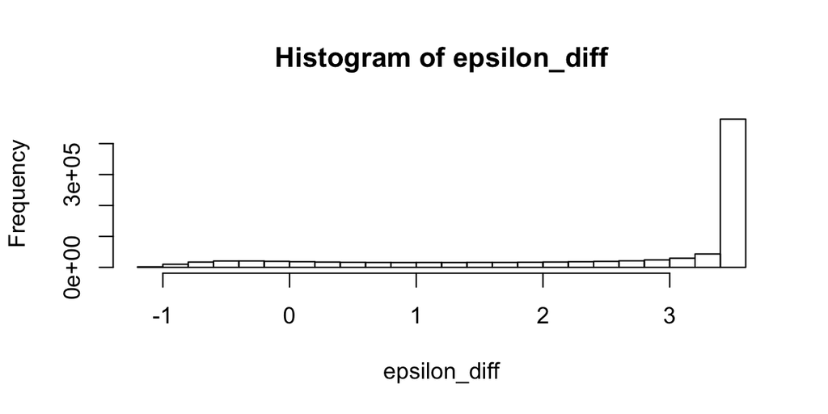

```r
# mean difference in variation over epsilon
epsilon_diff <- (pnorm(post1$epsilon) - pnorm(1-post1$epsilon)) / mean(expressionDiff)

hist(epsilon_diff)
```

```r
# howdoes epsilon compare to mu_a
mean(epsilon_diff) / mean(expressionDiff)
```

```
## [1] 9.039388
```

## Pregnancy Test

We next want to determine a ‘pregnancy test’ for the 12 individuals based on expression of the 10 ‘important’ genes using robust logistic regression.

Once we have nice tight distributions of coefficients for the 10 genes, those 10 genes could theoretically be used to predict pregnancy for an individual.

```r
# grab the posterior a's
post_a <- as.data.frame(summary(pipe_fit)[1])[1001:2000, 1] #extract the 1000 'a' coefficients

#Combined gene IDs with a's for the 1000 genes
genes_a <- as.data.frame(cbind(pipefish_data$Gene_ID, post_a))

# properly format numbers
genes_a$post_a <- as.numeric(as.character(genes_a$post_a))

# order from largest to smallest
genes_a <- genes_a[order(abs(genes_a[,2]), decreasing = TRUE),]

#Take five smallest and five largest a's by omitting all genes in between
test_genes <- genes_a[-c(11:1000),]

# these are the genes that show the largest change in expression
# between pregnant and non-pregnant fish based on our model fit.
test_genes
```

```
##                  V1     post_a
## 942 SSCG00000001316 -144.47597
## 944 SSCG00000001318 -115.43796
## 840 SSCG00000001178 -105.21661
## 769 SSCG00000001081  -99.99354
## 950 SSCG00000001327  -76.00729
## 658 SSCG00000000938  -74.05183
## 634 SSCG00000000901   73.78113
## 578 SSCG00000000828   71.27318
## 458 SSCG00000000662  -68.46805
## 120 SSCG00000000200   67.74444
```

```r
# get the rows for the coresponding genes
test_gene_rows <-  as.integer(rownames(test_genes))

# take the transpose of the ten test genes to fit the logit regression
ten_genes <- t(pipefish_data[2:13][test_gene_rows, ])
```

The model was run on Talapas, and saved in a .RData file. The data can be read in as follows.

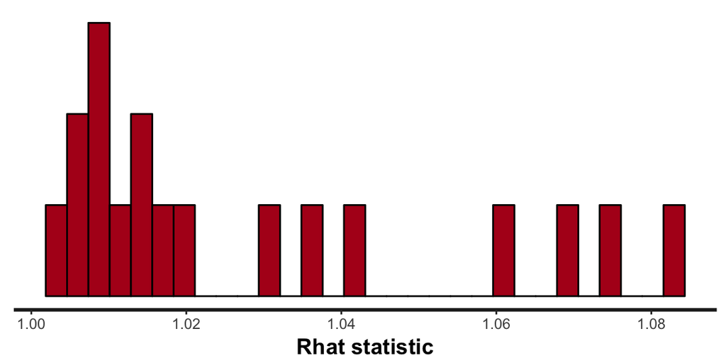

```r
Logit_model <- "
data {
    int N; // Number of fish
    int m; // Number of genes
    matrix[N, m] x; // matrix of Expression values for 10 gene panel
    int p[N]; // pregnancy status: c(rep(1,6), rep(0,6))
}
parameters{
  real b0;      // intercept (baseline expression)
  vector[m] c;  // coefficient of expression per gene

  real<lower=0> df_b;
  real<lower=0> df_a;

  real<lower=0> sigma_b;
  real<lower=0> sigma_a;

  real mu_b;
  real mu_a;
}
model {
  vector[N] y;
  y = b0 + x * c;
  p ~ bernoulli_logit(y);

  // Priors:
  b0 ~ student_t(df_b, mu_b, sigma_b);
  c ~ student_t(df_a, mu_a, sigma_a);

  // priors on b0 (expression on non-preg)
  mu_b ~ normal(0, 10);
  sigma_b ~ normal(0, 10);
  df_b ~ normal(0, 20);

  // priors on c (expression with preg)
  mu_a ~ normal(0, 10);
  sigma_a ~ normal(0, 10);
  df_a ~ normal(0, 20);
}
"

data_list = list(N=nrow(ten_genes),
                 m=ncol(ten_genes),
                 p = c(rep(1,6),rep(0,6)),
                 x = ten_genes)

# fit the model -- cache and comment for knitting
#ten_fit2 <- stan(model_code=Logit_model,
#                 data=data_list,
#                 chains=3, iter=1000,
#                 control = list(adapt_delta = 0.99,
#                                max_treedepth = 15))

# save that for later
#saveRDS(ten_fit2, "ten_fit2.rds")
fit1 <- readRDS("ten_fit2.rds")

# how is the rhat?
stan_rhat(fit1)
```

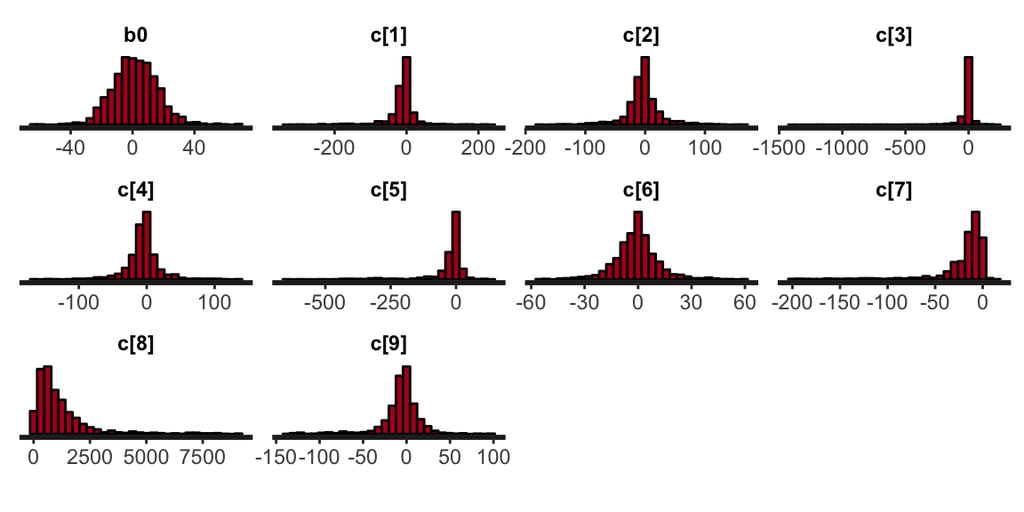

```r
# how are the coefficients distributed
stan_hist(fit1)
```

```r
summary(fit1)$summary
```

```
##                 mean      se_mean           sd         2.5%         25%
## b0         1.8034972   0.91782986   14.6485706  -24.5960933  -7.6604935
## c[1]     -12.1434799   4.47355224   44.4446501 -150.0871539 -17.8784034
## c[2]      -3.0610121   1.68601181   30.6068167  -73.3109919 -14.0790757
## c[3]     -21.7832003  11.86262729  106.7881592 -194.8776146 -17.9923918
## c[4]      -5.5155299   1.10625067   24.9660581  -62.7588946 -14.3190481
## c[5]     -28.3925859  22.98874427   77.1215090 -307.6492142 -24.0648657
## c[6]      -1.0616066   0.63017548   12.3158951  -27.6203626  -6.9805036
## c[7]     -20.6750942   5.01244282   30.6724334 -128.0403153 -21.8672567
## c[8]    1184.9507355 226.30824934 1301.0341903   75.0606743 426.1388907
## c[9]      -6.9640750   2.41286720   24.2948470  -79.4466096 -12.7396460
## c[10]    -11.5525799   2.02381603   28.3256178  -83.7843304 -17.1251458
## df_b      16.9899606   0.70242650   12.6684252    0.9580651   7.0312107
## df_a       0.8764712   0.05321786    0.6199044    0.2476367   0.4915621
## sigma_b    8.1511968   0.29859462    5.7966088    0.3006469   3.6512250
## sigma_a    8.3468448   0.50412295    5.6409967    0.3253366   4.1173445
## mu_b       0.8787965   0.57799728   10.2628519  -18.9395120  -6.2831221
## mu_a      -4.0480438   0.49812232    7.6167745  -18.8129052  -8.8920432
## lp__     -44.4371400   1.11554381    7.2754587  -57.9027161 -49.2934454
##                 50%          75%        97.5%     n_eff     Rhat
## b0        1.6303816   11.1022127   31.4221274 254.72181 1.009992
## c[1]     -6.5432417    1.8826603   53.6166406  98.70382 1.036943
## c[2]     -3.1237217    6.5116517   67.2896862 329.54528 1.010335
## c[3]     -5.9585750    3.1672629   61.2904255  81.03720 1.041234
## c[4]     -4.5512940    3.0066228   44.9469517 509.32250 1.005807
## c[5]     -7.9540313    1.8726472   34.4837728  11.25435 1.074296
## c[6]     -0.8456178    4.3863705   25.7368212 381.95215 1.007683
## c[7]    -11.3439910   -5.2572738    0.8740735  37.44532 1.062204
## c[8]    792.3921985 1452.8404831 5193.3926040  33.05039 1.083431
## c[9]     -3.7707951    3.6864157   29.5715585 101.38215 1.032007
## c[10]    -6.1048217    1.5765877   28.2124124 195.89201 1.012935
## df_b     14.4598128   24.5249735   48.0787260 325.26962 1.006716
## df_a      0.7426415    1.0615249    2.3859135 135.68586 1.013631
## sigma_b   7.1132345   11.4982874   21.2611078 376.86346 1.003722
## sigma_a   7.3543480   11.7501622   21.6992458 125.20992 1.019607
## mu_b      0.7370320    7.7827366   21.3369066 315.27137 1.016268
## mu_a     -3.9654516    0.5525838   11.9005358 233.81383 1.008447
## lp__    -44.6050161  -40.1967248  -28.7397174  42.53510 1.068792
```

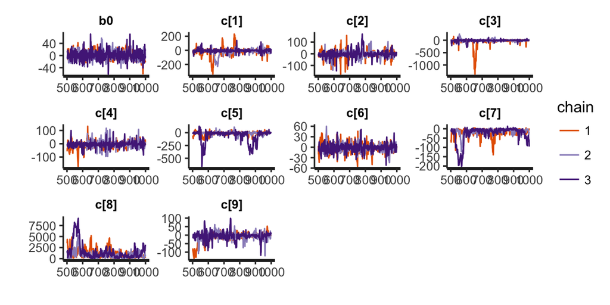

```r
stan_trace(fit1)
```

To make the ‘pregnancy test’ we can extract the posterior mean of coefficients ‘c’, and the intercept b0, and calculate the inverse logit from the linear combination of the data and these coefficients.

```r
# grab the posterior means for the paramters
params <- as.matrix(summary(fit1)$summary[1:11,1])

# intercept
intercept <- as.numeric(params[1])

# grab the coefficients posterior mean estimates
coeffs <- params[2:11]

# probability of each pregnancy
x <- intercept + ten_genes %*% coeffs

# return the inverse logit of x
1/(1+exp(-x))
```

```
##     [,1]
## P09    1
## P08    1
## P07    1
## P06    1
## P05    1
## P03    1
## N11    1
## N10    1
## N04    1
## N03    1
## N02    1
## N01    1
```

```r
coeffs_w8 <- coeffs
coeffs_w8[8] <- coeffs[8]*(1/10)


x_w9 <- intercept + ten_genes %*% coeffs_w8


# return the inverse logit of x
preg_stat <-  1/(1+exp(-x_w9))

preg_stat
```

```
##     [,1]
## P09    1
## P08    1
## P07    1
## P06    1
## P05    1
## P03    1
## N11    1
## N10    0
## N04    0
## N03    1
## N02    0
## N01    1
```

Putting a weight of 1/10th on this coefficient actually started to differentiate between pregnant and non-pregnant. Let’s increase the weight to 1/15 and see how that works..

```r
coeffs_w8 <- coeffs
coeffs_w8[8] <- coeffs[8]*(1/15)


x_w9 <- intercept + ten_genes %*% coeffs_w8


# return the inverse logit of x
preg_stat <-  1/(1+exp(-x_w9))

preg_stat
```

```
##     [,1]
## P09    1
## P08    1
## P07    1
## P06    1
## P05    1
## P03    1
## N11    0
## N10    0
## N04    0
## N03    0
## N02    0
## N01    0
```

Aha! A 1/15 weight on coefficient8 makes the prediction actually differentiate between pregnant and non-pregnant. To check out whats going on with this coefficient, let’s look back at the posterior predictions, and chains.

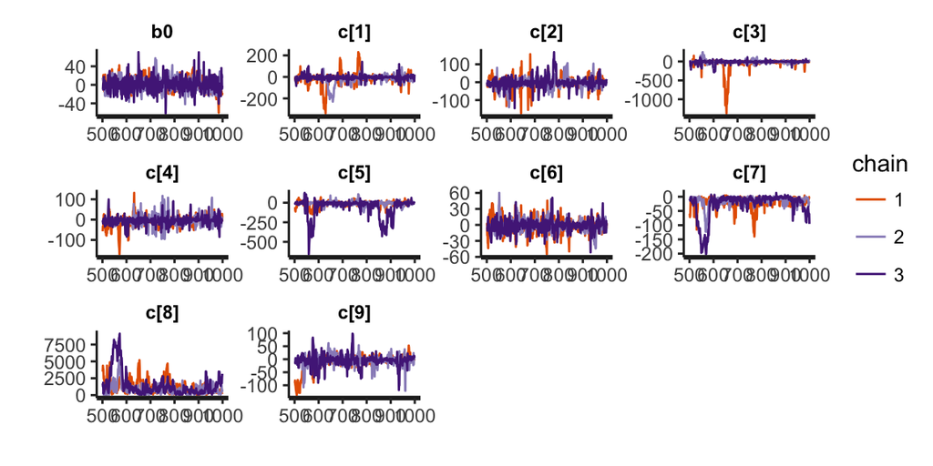

```r
stan_trace(fit1)
```

It’s clear that a posterior mean estimate of coefficient 8 will be skewed because of the lack of convergence of the chains..

Refining the logistic model could lead to cleaner mean posterior estimates of the coefficients and a better prediction test!